# Sage Days 114

## Institute of Mathematical Sceinces, Chennai (India)

### Institute of Chemical Technology, Mumbai

## What is Sagemath?

- SageMath is a free and open source sophisticated computer algebra system (CAS).
- It is built on to top of several free and open source mathemtical packages.

```
          For a full list see: https://www.sagemath.org/links-components.html
```

- SageMath distribution comprises of about 300 packages. https://github.com/sagemath/sage/tree/develop/build/pkgs
- It supports numerical computations, symbolic manipulations, graphing and complex progarmming.
- Viable open source alternative to: Mathematica, MatLAB, Maple, Magma.
- It was created by William Stein (https://www.wstein.org/) in 2005 as a platform which uses many free and open source mathematical software.
- Native language of SageMath is PYTHON.
- One can do python programming in Sagemath environment and also import Sage as a library in a Python script.
- SageMath is a very nice mathematical tool which can help in learning, teaching and researching in mathematics.
- SageMath has very nice interface with LaTeX.
- It is available for all platforms: Linux, Windows, Mac.
- It can be used online from www.cocalc.com and also through SageCell Server https://sagecell.sagemath.org/

## Why to use SageMath?

- It is FREE and with amazing capability.
- Being Python based, it is easy to learn and use.
- SageMath is a very nice Pedagogical tool.
- Can be used as a very useful research tool.

## Let us get started

### Dealing with integers

```python
726471264+36816
```

```
726508080
```

```python
sqrt(5.0)
```

```
2.23606797749979
```

```python
sqrt(5).n()
```

```
2.23606797749979
```

```python
show(sqrt(5))
```

$$\newcommand{\Bold}[1]{\mathbf{#1}}\sqrt{5}$$

```python
a = 615711658618567
```

```python
a.is_prime()
```

```
False
```

```python
a.factor()
```

```
7 * 87958808374081
```

```python
a.previous_prime()
```

```
615711658618493
```

```python
a.next_prime()
```

```
615711658618597
```

**Over Finite Fields**

```python
K.<a> = GF(5^45);K
```

```
Finite Field in a of size 5^45
```

```python
a.multiplicative_order()
```

```
229207334116161350281007828251
```

```python
a.is_square()
```

```
True
```

```python
b = a.square_root()
b
```

```
a^43 + 4*a^42 + 2*a^40 + 3*a^38 + a^37 + 2*a^36 + 4*a^35 + 3*a^32 + a^31 + 3*a^30 + 3*a^29 + 2*a^28 + 4*a^27 + 4*a^24 + 2*a^23 + 3*a^20 + 3*a^19 + 2*a^18 + 3*a^17 + 4*a^16 + a^15 + 3*a^13 + 2*a^12 + 4*a^11 + 3*a^10 + a^6 + 2*a^5 + 2*a^4 + 3*a^3
```

```python
b^2
```

```
a
```

```python
a, b = 282, 384
gcd(a,b)
```

```
6
```

```python
d, x, y = xgcd(a,b)
```

```python
print(d,x,y)
```

```
6 15 -11
```

```python
x*a+y*b == d
```

```
True
```

```python
P.<x> = QQ[]
F = (x^2 + 2)*x^3
G = (x^2+2)*(x-3)
g, u, v = QQ._xgcd_univariate_polynomial(F,G)
print(f'g={g}, u={u}, v={v}')
u*F + v*G==g # Verification of Bezout's Identity
```

```
g=x^2 + 2, u=1/27, v=-1/27*x^2 - 1/9*x - 1/3
```

```
True
```

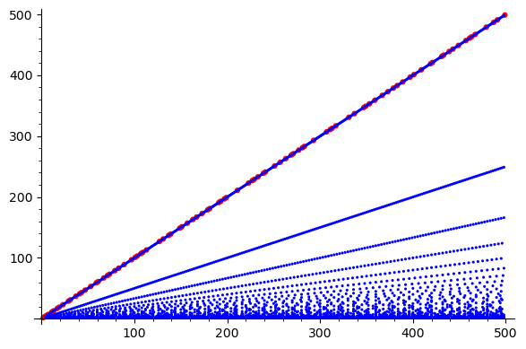

```python
P1 = []   # list of pairs (n,n) when n is prime
P2 = []   # list of pairs (n,d) where d|n and n is not prime
for n in xsrange(1,500):
    if n.is_prime():
        P1.append((n,n))
    else:
        P2.extend([(n,d) for d in n.divisors()[1:]])
G1 = point2d(P1,color='red',pointsize=20)
G2 = point2d(P2,color='blue',pointsize=5)
(G1 + G2).show()
```

### Exploring a function of on variable

Let us explore the function $$x^{2} + x e^{\left(-x^{2} + 2\right)} - 3 \, x + \sin\left(x^{2}\right) + 1$$

```python
f(x) = sin(x^2)+x*exp(2-x^2)+x^2-3*x+1
```

```python
show(f(x))
```

$$\newcommand{\Bold}[1]{\mathbf{#1}}x^{2} + x e^{\left(-x^{2} + 2\right)} - 3 \, x + \sin\left(x^{2}\right) + 1$$

```python
latex(f(x))
```

```
x^{2} + x e^{\left(-x^{2} + 2\right)} - 3 \, x + \sin\left(x^{2}\right) + 1
```

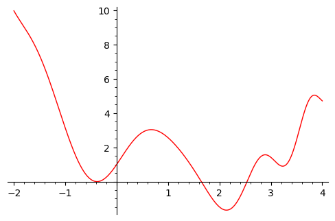

```python
f.plot(-2,4,color ='red',figsize=5)
```

```python
f.diff()
```

```
x |--> -2*x^2*e^(-x^2 + 2) + 2*x*cos(x^2) + 2*x + e^(-x^2 + 2) - 3
```

```python
f3 = f.diff(3)
```

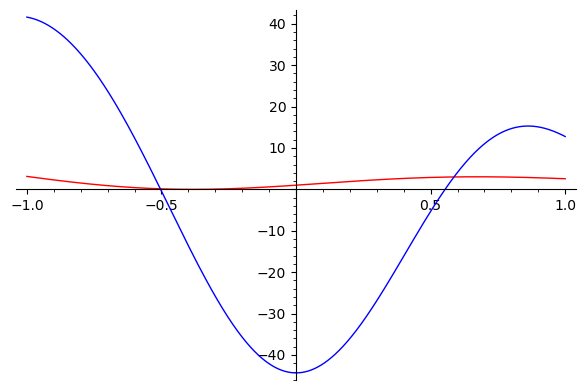

```python
f.plot(-1,1,color='red')+f3.plot(-1,1,color='blue')
```

```python
f.find_local_maximum(0,2)
```

```
(3.033075870198519, 0.672856583892896)
```

```python
f.find_root(1,2)
```

```
1.6460113287910914
```

```python
f.taylor(x,0,8)
```

```
x |--> -1/6*x^7*e^2 - 1/6*x^6 + 1/2*x^5*e^2 - x^3*e^2 + 2*x^2 + x*(e^2 - 3) + 1
```

### Solve Function

```python
#help(solve)
```

```python
reset()
```

```python
var('y')
sols = solve([x^3==y,y^2==x], [x,y]);
sols
```

[output not shown]

### Exploring function of more than one variables

```python
var('x,y')
f(x,y)=(x^2-y^2)*exp(-x^2-y^2)
```

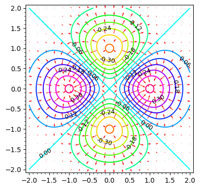

```python
ct = contour_plot(f(x,y),(x,-2,2),(y,-2,2),contours=12,fill=False,
                  labels=True,cmap='hsv',label_colors='black')
gr = f.gradient()
vf = plot_vector_field(gr,(x,-2,2),(y,-2,2),color='red')
ct+vf
```

```python
latex(f(x,y))
```

```
{\left(x^{2} - y^{2}\right)} e^{\left(-x^{2} - y^{2}\right)}
```

```python
plot3d(f(x,y),(x,-2,2),(y,-2,2))
```

[interactive chart not shown]

```python
f.diff(x)
```

```
(x, y) |--> -2*(x^2 - y^2)*x*e^(-x^2 - y^2) + 2*x*e^(-x^2 - y^2)
```

```python
f.diff(x,y)
```

```
(x, y) |--> 4*(x^2 - y^2)*x*y*e^(-x^2 - y^2)
```

```python
f.gradient()
```

```
(x, y) |--> (-2*(x^2 - y^2)*x*e^(-x^2 - y^2) + 2*x*e^(-x^2 - y^2), -2*(x^2 - y^2)*y*e^(-x^2 - y^2) - 2*y*e^(-x^2 - y^2))
```

```python
f.hessian()(x=1,y=-1)
```

```
[-6*e^(-2)         0]
[        0  6*e^(-2)]
```

## Working with vectors and Matrices

```python
v = vector(QQ,[-2,3])
u = vector(QQ,[1,-1])
```

```python
reset()
```

```python
A = matrix(QQ, [
    [1, 1, 2, -1 ,1, 1],
    [-6, 3, 7, -3, 0, 3],
    [-2, 0, 5, -1, 0, 1],
    [-10, 0, 10, -2, 1, 5],
    [2, 0, -2, 1, 3, -1],
    [-6, 2, 6, -3, 3, 6]])
```

```python
A.jordan_form()
```

```
[1|0 0 0|0 0]
[-+-----+---]
[0|3 1 0|0 0]
[0|0 3 1|0 0]
[0|0 0 3|0 0]
[-+-----+---]
[0|0 0 0|3 1]
[0|0 0 0|0 3]
```

```python
@interact
def linear_transformation(A=matrix(QQ,[[1,1],[1/2,-1]]),
            u=matrix(QQ,[2,2]),v=matrix(QQ,[-1,2])):
    u=vector(QQ,[u[0,0],u[0,1]])
    v=vector(QQ,[v[0,0],v[0,1]])
    r =1.1
    e=vector(QQ,[1/10,1/10])
    u1 = A*u
    v1 = A*v
    p1=plot(u,color='red')+plot(v,color='green')
    p1=p1+plot(u+v,color='blue')
    p1=p1+line((u,u+v),linestyle="--",color='black')
    p1=p1+line((v,u+v),linestyle="--",color='black')
    p2=plot(A*u,color='red')+plot(A*v,color='green')
    p2=p2+plot(A*(u+v),color='blue')
    p2=p2+line((A*u,A*(u+v)),linestyle="--",color='black')
    p2=p2+line((A*v,A*(u+v)),linestyle="--",color='black')
    t=text('$u$',r*u)+text('$v$',r*v)+text('$u+v$',r*(u+v))
    t=t+text('$Au$',r*A*u,color='red')+text('$Av$',r*A*v,color='red')+text('$A(u+v)$',r*A*(u+v),color='red')
    show(p1+p2+t,aspect_ratio=1)
```

## Working with Groups

```python
G =SymmetricGroup(6)
```

```python
a = G.random_element()
```

```python
a.order()
```

```
6
```

```python
G = GL(3,5)
S = SL(3,5)
```

```python
G.order()
S.order()
```

```
372000
```

### Sylow Subgroup in GL(n, GF(5))

```python
n,p=2,5
G = GL(n,GF(p))
print(G.order())
print(factor(G.order()))
```

```
480
2^5 * 3 * 5
```

```python
O2 = [g for g in G if g.multiplicative_order()==2]
O4 = [g for g in G if g.multiplicative_order()==4]
(len(O2),len(O4))
```

```
(31, 152)
```

```python
for i in range(len(O2)):
    for j in range(len(O4)):
        A,B= O4[i],O4[j]
        H = MatrixGroup([matrix(GF(p),n,flatten(A.list())),
                              matrix(GF(p),n,flatten(B.list()))]);
        if(H.order()==32):
            break
print(H.order())
```

```
32
```

### Lattice of Subgroups

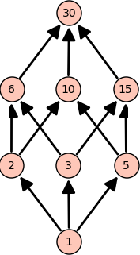

```python
G = CyclicPermutationGroup(30)
subgroups = G.subgroups()
P = Poset((subgroups, lambda h,k: h.is_subgroup(k)))
relabeling = {h:h.order() for (i,h) in enumerate(P)}
Q = P.relabel(relabeling)
LZ30_2=Q.plot(figsize=5,element_size=500)
LZ30_2
```

**Image processing usng SVD from Python Numpy**

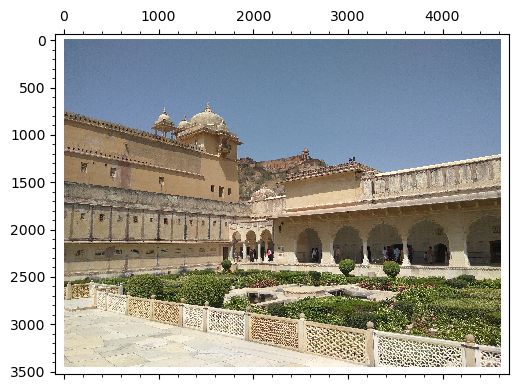

```python
from matplotlib.pyplot import imread
import pylab
import numpy as np
img=pylab.imread('Image2.png')
matrix_plot(img)
```

```python
R1 = img[:,:,0] # Red channel
G1 = img[:,:,1] # Green Channel
B1 = img[:,:,2] # Blue Channel
```

```python
R1.shape,G1.shape,B1.shape
```

```
((3456, 4608), (3456, 4608), (3456, 4608))
```

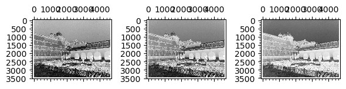

```python
graphics_array([matrix_plot(R1),matrix_plot(G1),matrix_plot(B1)])
```

```python
img.shape
```

```
(3456, 4608, 3)
```

```python
img_transposed = np.transpose(img, (2, 0, 1))
img_transposed.shape
```

```
(3, 3456, 4608)
```

```python
U, s, Vt = np.linalg.svd(img_transposed)
```

```python
Sigma = np.zeros(img_transposed.shape)
for j in range(3):
    np.fill_diagonal(Sigma[j, :, :], s[j, :])
```

```python
Sigma.shape
```

```
(3, 3456, 4608)
```

```python
reconstructed = U @ Sigma @ Vt
```

```
Clipping input data to the valid range for imshow with RGB data ([0..1] for floats or [0..255] for integers).
```

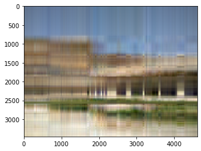

```python
k= 5
approx_img = U @ Sigma[..., :k] @ Vt[..., :k, :]
pylab.imshow(np.transpose(approx_img, (1, 2, 0)))
```

```
Clipping input data to the valid range for imshow with RGB data ([0..1] for floats or [0..255] for integers).
```

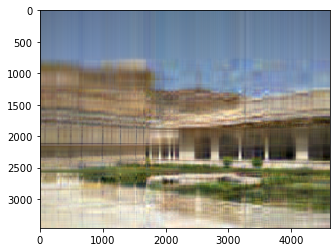

```python
k= 10
approx_img = U @ Sigma[..., :k] @ Vt[..., :k, :]
pylab.imshow(np.transpose(approx_img, (1, 2, 0)))
```

```
Clipping input data to the valid range for imshow with RGB data ([0..1] for floats or [0..255] for integers).
```

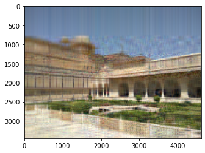

```python
k= 20
approx_img = U @ Sigma[..., :k] @ Vt[..., :k, :]
pylab.imshow(np.transpose(approx_img, (1, 2, 0)))
```

```
Clipping input data to the valid range for imshow with RGB data ([0..1] for floats or [0..255] for integers).
```

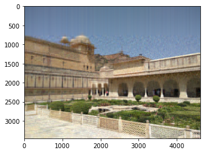

```python
k= 50
approx_img = U @ Sigma[..., :k] @ Vt[..., :k, :]
pylab.imshow(np.transpose(approx_img, (1, 2, 0)))
```

```
Clipping input data to the valid range for imshow with RGB data ([0..1] for floats or [0..255] for integers).
```

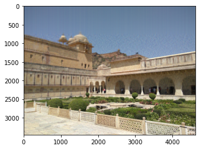

```python
k= 100
approx_img = U @ Sigma[..., :k] @ Vt[..., :k, :]
pylab.imshow(np.transpose(approx_img, (1, 2, 0)))
```

**References**

1. Sagemath documentations: https://doc.sagemath.org/
2. Computational Mathematics with Sagemath by Paul Zimmerman
3. Online book on Linear Algebra by Robert Beezer
4. Series of YouTube video lectures (Twelve) on SageMath by Ajit Kumar

##### ajitmathsoft.wordpress.com/sagemath

5. NPTEL course on Computational Matheatics with Sagemath by Ajit Kumar https://onlinecourses.nptel.ac.in/noc22_ma24/preview
6. Group Threory: A expedition with SageMath by Ajit Kumar and Vikas Bist.